# Maternal Mortality Rates in Africa

BAA1030 - Data Analytics and Story Telling

Author

Daniel Reynolds

Published

April 27, 2025

```python
from IPython.core.display import HTML

def set_custom_styles():
    css = """
    <style>
        body {
            background-color: #f0f8ff;  /* Light blue background */
            font-family: 'Roboto', sans-serif;  /* Font set to Roboto */
        }
        h1, h2, h3 {
            color: #4CAF50;  /* Green color for headers */
        }
        .input {
            background-color: #ffffff;  /* White background for input cells */
        }
        .output {
            background-color: #ffffff;  /* White background for output cells */
            border-radius: 10px;  /* Rounded corners */
        }
    </style>
    """
    display(HTML(css))

set_custom_styles()
```

[figure not shown]

OIP.jpg

[figure not shown]

R.jpg

# Table of Contents

1. Introduction
2. Maternal Mortality: Africa vs Global Average
3. Maternal Mortality vs GDP per Capita
4. World Map
5. Top 10 Maternal Mortality Countries
6. Bottom 10 Maternal Mortality Countries
7. Conclusion

# *Introduction*

This is an analysis on a pressing issue in the continent of Africa: *Maternal Mortality*. We will analyse the figures of the decline of *maternal mortality* from 2020 to 2000. This will be done through the visualisations seen below. We will examine different factors that can contribute to high numbers of *maternal mortality* and that is *GDP per capita*. This analysis will concur if low levels of *GDP* correlate to high levels of *maternal mortality*.

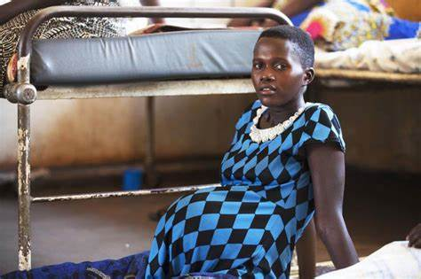

OIP (1).jpg

```python
import pandas as pd
import geopandas as gpd
import matplotlib.pyplot as plt
import seaborn as sns
```

```python
file_path = '/content/drive/My Drive/unicef-data/unicef_indicator_1.csv'
indicator_1 = pd.read_csv(file_path)
file_path = '/content/drive/My Drive/unicef-data/unicef_indicator_2.csv'
indicator_2 = pd.read_csv(file_path)
file_path = '/content/drive/My Drive/unicef-data/unicef_metadata.csv'
metadata = pd.read_csv(file_path)
```

```python
import pandas as pd
maternal_mortality_in_indicator_2 = indicator_2[indicator_2['indicator'].str.contains('maternal', case=False, na=False)]
maternal_mortality_data_filtered = maternal_mortality_in_indicator_2[maternal_mortality_in_indicator_2['time_period'] >= 2000]
african_countries = [
    'DZA', 'AGO', 'BWA', 'BFA', 'BDI', 'CMR', 'CPV', 'CAF', 'TCD', 'COM', 'COD', 'COG', 'DJI', 'EGY',
    'GNQ', 'ERI', 'SWZ', 'ETH', 'GAB', 'GMB', 'GHA', 'GIN', 'GNB', 'CIV', 'KEN', 'LSO', 'LBR', 'LBY',
    'MDG', 'MWI', 'MRT', 'MUS', 'MOZ', 'NAM', 'NER', 'NGA', 'RWA', 'STP', 'SEN', 'SYC', 'SLE', 'SOM',
    'ZAF', 'SSD', 'SDN', 'TGO', 'TUN', 'UGA', 'TZA', 'ZMB', 'ZWE'
]
african_maternal_mortality = maternal_mortality_data_filtered[maternal_mortality_data_filtered['alpha_3_code'].isin(african_countries)]
africa_avg_mortality = african_maternal_mortality.groupby('time_period')['obs_value'].mean().reset_index()
africa_avg_mortality['country'] = 'Africa'
global_avg_mortality = maternal_mortality_data_filtered.groupby('time_period')['obs_value'].mean().reset_index()
global_avg_mortality['country'] = 'Global'
combined_data = pd.concat([africa_avg_mortality[['time_period', 'obs_value', 'country']],
                           global_avg_mortality[['time_period', 'obs_value', 'country']]],
                          ignore_index=True)
```

# *Maternal Mortality: Africa vs Global Average*

The time series chart below highlights the harsh reality of the high levels of *mortality* in Africa compared to the rest of the world. Although the ratio in Africa has significantly improved, dropping by almost 300 deaths in 20 years, the current number is still concerning. The data from 2020 highlights that many African countries continue to face challenges such as:

- limited healthcare infrastructure
- inadequate access to skilled healthcare professionals
- socio-economic barriers

The graph shows great progress in reducing the numbers, but they are not nearly as low as they should be. International health organisations and national governments need to implement more comprehensive maternal health programs in African regions. Targeted interventions are needed in Africa to improve maternal healthcare access, reduce preventable deaths, and work toward achieving the United Nations Sustainable Development Goal of reducing *maternal mortality*.

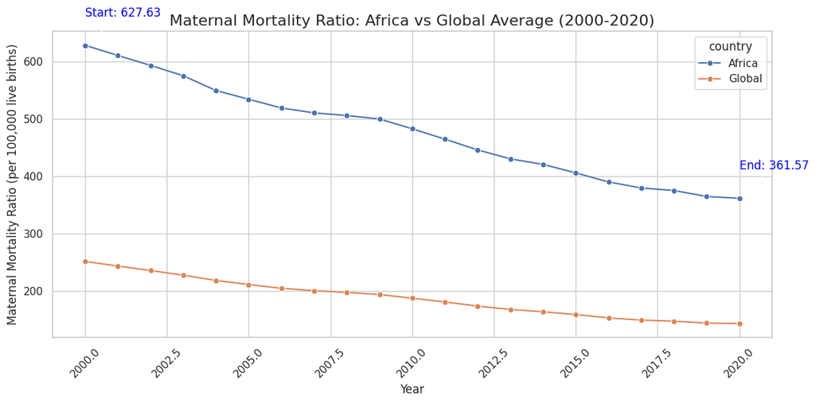

```python
import seaborn as sns
import matplotlib.pyplot as plt
sns.set(style="whitegrid")
plt.figure(figsize=(12, 6))
sns.lineplot(data=combined_data, x='time_period', y='obs_value', hue='country', marker="o")
plt.title("Maternal Mortality Ratio: Africa vs Global Average (2000-2020)", fontsize=16)
plt.xlabel("Year", fontsize=12)
plt.ylabel("Maternal Mortality Ratio (per 100,000 live births)", fontsize=12)
plt.xticks(rotation=45)

plt.annotate(f"Start: {africa_avg_mortality['obs_value'].iloc[0]:.2f}",
             xy=(2000, africa_avg_mortality['obs_value'].iloc[0]),
             xytext=(2000, africa_avg_mortality['obs_value'].iloc[0]+50),
             arrowprops=dict(facecolor='blue', arrowstyle='->'),
             fontsize=12, color='blue')
plt.annotate(f"End: {africa_avg_mortality['obs_value'].iloc[-1]:.2f}",
             xy=(2020, africa_avg_mortality['obs_value'].iloc[-1]),
             xytext=(2020, africa_avg_mortality['obs_value'].iloc[-1]+50),
             arrowprops=dict(facecolor='blue', arrowstyle='->'),
             fontsize=12, color='blue')
plt.tight_layout()
plt.show()
```

# *Maternal Mortality vs GDP per Capita*

The scatter plot below shows the direct correlation between the number of *maternal mortality* in a country alongside its *GDP per Capita* for the year. The plot reveals a negative correlation, suggesting that higher GDP per capita is generally associated with lower *maternal mortality* rates in African countries. The regression line highlights the overall trend, showing that countries with wealthier economies tend to have better healthcare systems, which can lead to improved maternal health outcomes. There are many outliers amongst the data suggesting the issue of *maternal mortality* has other determinants apart from *GDP*. The complexity of maternal health needs to be addressed through improving healthcare access and quality in countries with both low and medium *GDP per Capita*.

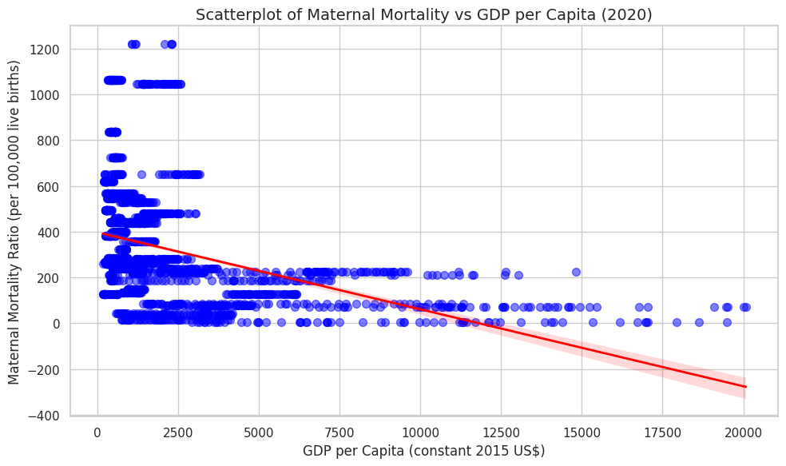

```python
import seaborn as sns
import matplotlib.pyplot as plt
scatter_data_gdp = pd.merge(
    african_maternal_mortality[['country', 'time_period', 'obs_value']],
    metadata[['country', 'GDP per capita (constant 2015 US$)']],
    on='country', how='inner'
)
scatter_data_gdp_2020 = scatter_data_gdp[scatter_data_gdp['time_period'] == 2020]
plt.figure(figsize=(10, 6))
sns.regplot(
    x='GDP per capita (constant 2015 US$)',
    y='obs_value',
    data=scatter_data_gdp_2020,
    scatter_kws={'color': 'blue', 's': 50, 'alpha': 0.5},
    line_kws={'color': 'red', 'lw': 2},
    robust=True,
)
plt.title("Scatterplot of Maternal Mortality vs GDP per Capita (2020)", fontsize=14)
plt.xlabel("GDP per Capita (constant 2015 US$)", fontsize=12)
plt.ylabel("Maternal Mortality Ratio (per 100,000 live births)", fontsize=12)
plt.tight_layout()
plt.show()
```

```python
import zipfile
import os
zip_file_path = '/content/drive/MyDrive/countries/map-countries.zip'
extracted_folder = '/content/drive/MyDrive/countries/extracted_shapefile/'
with zipfile.ZipFile(zip_file_path, 'r') as zip_ref:
    zip_ref.extractall(extracted_folder)
extracted_files = os.listdir(extracted_folder)
print(extracted_files)
```

```
['ne_110m_admin_0_countries.README.html', 'ne_110m_admin_0_countries.shx', 'ne_110m_admin_0_countries.VERSION.txt', 'ne_110m_admin_0_countries.shp', 'ne_110m_admin_0_countries.dbf', 'ne_110m_admin_0_countries.cpg', 'ne_110m_admin_0_countries.prj']
```

# *World Map*

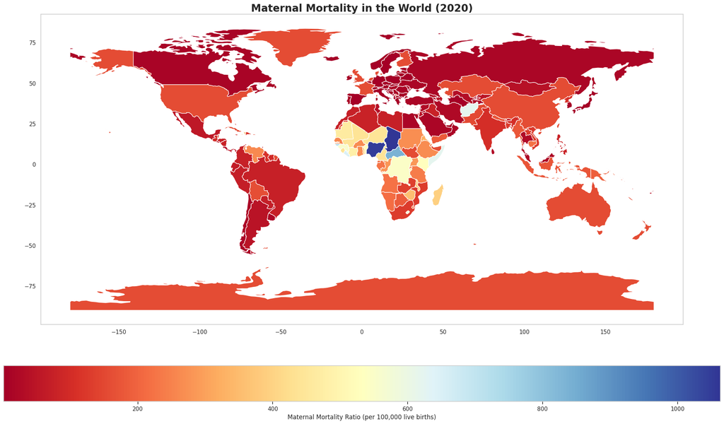

```python
import geopandas as gpd
import pandas as pd
import matplotlib.pyplot as plt
shapefile_path = '/content/drive/MyDrive/countries/extracted_shapefile/ne_110m_admin_0_countries.shp'
world = gpd.read_file(shapefile_path)
world_maternal_mortality_2020 = maternal_mortality_data_filtered[maternal_mortality_data_filtered['time_period'] == 2020]
world_map_data_2020 = world.set_index('SOV_A3').join(world_maternal_mortality_2020.set_index('alpha_3_code')['obs_value'])
world_map_data_2020['obs_value'] = world_map_data_2020['obs_value'].fillna(world_map_data_2020['obs_value'].mean())  # or use dropna() if preferred
sorted_world_2020 = world_map_data_2020.sort_values(by='obs_value', ascending=False)
fig, ax = plt.subplots(1, 1, figsize=(20, 12))
world_map_data_2020.plot(column='obs_value', ax=ax, legend=True,
                         legend_kwds={'label': "Maternal Mortality Ratio (per 100,000 live births)",
                                      'orientation': "horizontal", 'pad': 0.1},
                         cmap='RdYlBu')
ax.grid(False)
plt.title("Maternal Mortality in the World (2020)", fontsize=20, weight='bold')
plt.tight_layout()
plt.show()
```

```python
import geopandas as gpd
import pandas as pd
import matplotlib.pyplot as plt
shapefile_path = '/content/drive/MyDrive/countries/extracted_shapefile/ne_110m_admin_0_countries.shp'
world = gpd.read_file(shapefile_path)
world_maternal_mortality = maternal_mortality_data_filtered[maternal_mortality_data_filtered['alpha_3_code'].notnull()]
world_map_data = world.set_index('SOV_A3').join(world_maternal_mortality.set_index('alpha_3_code')['obs_value'])
world_map_data['obs_value'] = world_map_data['obs_value'].fillna(world_map_data['obs_value'].mean())
sorted_world = world_map_data.sort_values(by='obs_value', ascending=False)
fig, ax = plt.subplots(1, 1, figsize=(20, 12))
world_map_data.plot(column='obs_value', ax=ax, legend=True,
                    legend_kwds={'label': "Maternal Mortality Ratio (per 100,000 live births)",
                                 'orientation': "horizontal", 'pad': 0.1},
                    cmap='RdYlBu')
ax.set_axis_off()
ax.grid(False)
plt.title("Maternal Mortality in the World (2000)", fontsize=20, weight='bold')
plt.tight_layout()
plt.show()
```

[output not shown]

# *Top 10 Maternal Mortality Countries*

```python
import pandas as pd
import matplotlib.pyplot as plt
maternal_mortality_2020 = maternal_mortality_data_filtered[maternal_mortality_data_filtered['time_period'] == 2020]
top_10_2020 = maternal_mortality_2020.sort_values(by='obs_value', ascending=False).head(10)
maternal_mortality_2000 = maternal_mortality_data_filtered[maternal_mortality_data_filtered['time_period'] == 2000]
top_10_2000 = maternal_mortality_2000.sort_values(by='obs_value', ascending=False).head(10)
plt.figure(figsize=(14, 8))
plt.subplot(1, 2, 1)
bars_2020 = plt.barh(top_10_2020['country'], top_10_2020['obs_value'], color='darkred')
for i, bar in enumerate(bars_2020):
    plt.text(bar.get_width() + 2, bar.get_y() + bar.get_height() / 2, f'{top_10_2020["obs_value"].iloc[i]:.2f}',
             va='center', fontsize=12, color='black')

plt.xlabel('Maternal Mortality Ratio (per 100,000 live births)', fontsize=12)
plt.ylabel('Country', fontsize=12)
plt.title('Top 10 African Countries by Maternal Mortality (2020)', fontsize=16, weight='bold')
plt.gca().invert_yaxis()
plt.subplot(1, 2, 2)
bars_2000 = plt.barh(top_10_2000['country'], top_10_2000['obs_value'], color='darkred')
for i, bar in enumerate(bars_2000):
    plt.text(bar.get_width() + 2, bar.get_y() + bar.get_height() / 2, f'{top_10_2000["obs_value"].iloc[i]:.2f}',
             va='center', fontsize=12, color='black')

plt.xlabel('Maternal Mortality Ratio (per 100,000 live births)', fontsize=12)
plt.ylabel('Country', fontsize=12)
plt.title('Top 10 African Countries by Maternal Mortality (2000)', fontsize=16, weight='bold')
plt.tight_layout()
plt.gca().invert_yaxis()
plt.show()
```

[output not shown]

# *Bottom 10 Maternal Mortality Countries*

```python
import pandas as pd
import matplotlib.pyplot as plt
maternal_mortality_2020 = maternal_mortality_data_filtered[
    maternal_mortality_data_filtered['alpha_3_code'].isin(african_countries) &
    (maternal_mortality_data_filtered['time_period'] == 2020)
]
bottom_10_2020 = maternal_mortality_2020.sort_values(by='obs_value', ascending=True).head(10)
maternal_mortality_2000 = maternal_mortality_data_filtered[
    maternal_mortality_data_filtered['alpha_3_code'].isin(african_countries) &
    (maternal_mortality_data_filtered['time_period'] == 2000)
]
bottom_10_2000 = maternal_mortality_2000.sort_values(by='obs_value', ascending=True).head(10)
plt.figure(figsize=(14, 8))
plt.subplot(1, 2, 1)
bars_2020 = plt.barh(bottom_10_2020['country'], bottom_10_2020['obs_value'], color='green')
for i, bar in enumerate(bars_2020):
    plt.text(bar.get_width() + 2, bar.get_y() + bar.get_height() / 2, f'{bottom_10_2020["obs_value"].iloc[i]:.2f}',
             va='center', fontsize=12, color='black')

plt.xlabel('Maternal Mortality Ratio (per 100,000 live births)', fontsize=12)
plt.ylabel('Country', fontsize=12)
plt.title('Bottom 10 African Countries by Maternal Mortality (2020)', fontsize=14, weight='bold')
plt.gca().invert_yaxis()
plt.subplot(1, 2, 2)
bars_2000 = plt.barh(bottom_10_2000['country'], bottom_10_2000['obs_value'], color='green')
for i, bar in enumerate(bars_2000):
    plt.text(bar.get_width() + 2, bar.get_y() + bar.get_height() / 2, f'{bottom_10_2000["obs_value"].iloc[i]:.2f}',
             va='center', fontsize=12, color='black')

plt.xlabel('Maternal Mortality Ratio (per 100,000 live births)', fontsize=12)
plt.ylabel('Country', fontsize=12)
plt.title('Bottom 10 African Countries by Maternal Mortality (2000)', fontsize=14, weight='bold')
plt.gca().invert_yaxis()
plt.tight_layout()
plt.show()
```

[output not shown]

# Conclusion

The current data shows a relationship between *Maternal Mortality* and *GDP per Capita*. Most countries align with the consensus of low *GDP* = high *maternal mortality*, although there are some outliers, such as Nigeria and Mozambique. Although *GDP* is not a direct answer to solving *maternal mortality*, it helps address other issues that poorer countries are incapable of addressing. From 2000 to 2020, we can see a consistent drop in *maternal mortality* across the continent, which is great progress, but the numbers are still far too high to claim the problem is fixed. Many of the countries who have poor numbers are generally areas that are conflict-affected or fragile. Prevention strategies should be integrated into humanitarian response, and maternal health should also be prioritised in climate adaptation plans to address these emerging threats that are affecting the well-being of pregnant women. With the figures presented, we can see a generally strong connection between the two variables. Unfortunately, the comparison between the two is not constant and predictable; therefore, we can infer that high *GDP* is crucial to reducing *maternal mortality* in Africa, but other factors and variables can help tackle the poor statistics around quality and infrastructure in the corresponding healthcare systems.

```python
!quarto render "/content/drive/MyDrive/Colab Notebooks/FinalDraft.ipynb"
```